# Ensemble Techniques Project

```python
#importing the basic libraries
import numpy as np
import pandas as pd
import scipy.stats as stats
import matplotlib.pyplot as plt
import seaborn as sns
sns.set_style("darkgrid")
%matplotlib inline
import warnings
warnings.filterwarnings("ignore")
```

**DOMAIN: TELECOM**  
**CONTEXT :** A telecom company wants to use their historical customer data to predict behaviour to retain customers. You can analyse all relevant customer data and develop focused customer retention programs.  
**DATA DESCRIPTION :** Each row represents a customer, each column contains customer’s attributes described on the column Metadata. The data set includes information about:

Customers who left within the last month – the column is called Churn.

Services that each customer has signed up for – phone, multiple lines, internet, online security, online backup, device protection, tech support, and streaming TV and movies.

Customer account information – how long they’ve been a customer, contract, payment method, paperless billing, monthly charges, and total charges.

Demographic info about customers – gender, age range, and if they have partners and dependents  
**PROJECT OBJECTIVE :** Build a model that will help to identify the potential customers who have a higher probability to churn. This help the company to understand the pinpoints and patterns of customer churn and will increase the focus on strategising customer retention.

#### 1. Import and warehouse data:

• Import all the given datasets and explore shape and size of each.  
• Merge all datasets onto one and explore final shape and size.

**Import the DataSets**

```python
df1 = pd.read_csv(r'C:\Users\Paridhi Paliwal\Great Learning Study Material\Ensemble Techniques\Ensemble Techniques Project\DB1.csv')
df2 = pd.read_csv(r'C:\Users\Paridhi Paliwal\Great Learning Study Material\Ensemble Techniques\Ensemble Techniques Project\DB2.csv')
```

**Shape and Size of datasets**

```python
df1.shape,df2.shape
```

```
((7043, 10), (7043, 11))
```

```python
df1.size , df2.size
```

```
(70430, 77473)
```

```python
print ("The first dataset has", df1.shape[0],"rows and", df1.shape[1]," columns")
print ("The second dataset has", df2.shape[0],"rows and", df2.shape[1]," columns")
print ("The first dataset has",df1.size,"elements")
print ("The second dataset has",df2.size,"elements")
```

```
The first dataset has 7043 rows and 10  columns
The second dataset has 7043 rows and 11  columns
The first dataset has 70430 elements
The second dataset has 77473 elements
```

```python
df1.head()
```

|  | customerID | gender | SeniorCitizen | Partner | Dependents | tenure | PhoneService | MultipleLines | InternetService | OnlineSecurity |
| --- | --- | --- | --- | --- | --- | --- | --- | --- | --- | --- |
| 0 | 7590-VHVEG | Female | 0 | Yes | No | 1 | No | No phone service | DSL | No |
| 1 | 5575-GNVDE | Male | 0 | No | No | 34 | Yes | No | DSL | Yes |
| 2 | 3668-QPYBK | Male | 0 | No | No | 2 | Yes | No | DSL | Yes |
| 3 | 7795-CFOCW | Male | 0 | No | No | 45 | No | No phone service | DSL | Yes |
| 4 | 9237-HQITU | Female | 0 | No | No | 2 | Yes | No | Fiber optic | No |

```python
df2.head()
```

|  | OnlineBackup | DeviceProtection | TechSupport | StreamingTV | StreamingMovies | Contract | PaperlessBilling | PaymentMethod | MonthlyCharges | TotalCharges | Churn |
| --- | --- | --- | --- | --- | --- | --- | --- | --- | --- | --- | --- |
| 0 | Yes | No | No | No | No | Month-to-month | Yes | Electronic check | 29.85 | 29.85 | No |
| 1 | No | Yes | No | No | No | One year | No | Mailed check | 56.95 | 1889.5 | No |
| 2 | Yes | No | No | No | No | Month-to-month | Yes | Mailed check | 53.85 | 108.15 | Yes |
| 3 | No | Yes | Yes | No | No | One year | No | Bank transfer (automatic) | 42.30 | 1840.75 | No |
| 4 | No | No | No | No | No | Month-to-month | Yes | Electronic check | 70.70 | 151.65 | Yes |

```python
df1.tail()
```

|  | customerID | gender | SeniorCitizen | Partner | Dependents | tenure | PhoneService | MultipleLines | InternetService | OnlineSecurity |
| --- | --- | --- | --- | --- | --- | --- | --- | --- | --- | --- |
| 7038 | 6840-RESVB | Male | 0 | Yes | Yes | 24 | Yes | Yes | DSL | Yes |
| 7039 | 2234-XADUH | Female | 0 | Yes | Yes | 72 | Yes | Yes | Fiber optic | No |
| 7040 | 4801-JZAZL | Female | 0 | Yes | Yes | 11 | No | No phone service | DSL | Yes |
| 7041 | 8361-LTMKD | Male | 1 | Yes | No | 4 | Yes | Yes | Fiber optic | No |
| 7042 | 3186-AJIEK | Male | 0 | No | No | 66 | Yes | No | Fiber optic | Yes |

```python
df2.tail()
```

|  | OnlineBackup | DeviceProtection | TechSupport | StreamingTV | StreamingMovies | Contract | PaperlessBilling | PaymentMethod | MonthlyCharges | TotalCharges | Churn |
| --- | --- | --- | --- | --- | --- | --- | --- | --- | --- | --- | --- |
| 7038 | No | Yes | Yes | Yes | Yes | One year | Yes | Mailed check | 84.80 | 1990.5 | No |
| 7039 | Yes | Yes | No | Yes | Yes | One year | Yes | Credit card (automatic) | 103.20 | 7362.9 | No |
| 7040 | No | No | No | No | No | Month-to-month | Yes | Electronic check | 29.60 | 346.45 | No |
| 7041 | No | No | No | No | No | Month-to-month | Yes | Mailed check | 74.40 | 306.6 | Yes |
| 7042 | No | Yes | Yes | Yes | Yes | Two year | Yes | Bank transfer (automatic) | 105.65 | 6844.5 | No |

**Merging the datasets into a combined dataset**

```python
df= pd.concat([df1,df2],axis=1,join='outer')
df.head()
```

|  | customerID | gender | SeniorCitizen | Partner | Dependents | tenure | PhoneService | MultipleLines | InternetService | OnlineSecurity | ... | DeviceProtection | TechSupport | StreamingTV | StreamingMovies | Contract | PaperlessBilling | PaymentMethod | MonthlyCharges | TotalCharges | Churn |
| --- | --- | --- | --- | --- | --- | --- | --- | --- | --- | --- | --- | --- | --- | --- | --- | --- | --- | --- | --- | --- | --- |
| 0 | 7590-VHVEG | Female | 0 | Yes | No | 1 | No | No phone service | DSL | No | ... | No | No | No | No | Month-to-month | Yes | Electronic check | 29.85 | 29.85 | No |
| 1 | 5575-GNVDE | Male | 0 | No | No | 34 | Yes | No | DSL | Yes | ... | Yes | No | No | No | One year | No | Mailed check | 56.95 | 1889.5 | No |
| 2 | 3668-QPYBK | Male | 0 | No | No | 2 | Yes | No | DSL | Yes | ... | No | No | No | No | Month-to-month | Yes | Mailed check | 53.85 | 108.15 | Yes |
| 3 | 7795-CFOCW | Male | 0 | No | No | 45 | No | No phone service | DSL | Yes | ... | Yes | Yes | No | No | One year | No | Bank transfer (automatic) | 42.30 | 1840.75 | No |
| 4 | 9237-HQITU | Female | 0 | No | No | 2 | Yes | No | Fiber optic | No | ... | No | No | No | No | Month-to-month | Yes | Electronic check | 70.70 | 151.65 | Yes |

5 rows × 21 columns

```python
df.shape, df.size
```

```
((7043, 21), 147903)
```

```python
print ("The final dataset has", df.shape[0],"rows and",df.shape[1]," columns",'and',df.size,'elements.')
```

```
The final dataset has 7043 rows and 21  columns and 147903 elements.
```

#### 2.Data cleansing:

• Missing value treatment  
• Convert categorical attributes to continuous using relevant functional knowledge  
• Drop attribute/s if required using relevant functional knowledge  
• Automate all the above steps

```python
df.info()
```

```
<class 'pandas.core.frame.DataFrame'>
RangeIndex: 7043 entries, 0 to 7042
Data columns (total 21 columns):
 #   Column            Non-Null Count  Dtype
---  ------            --------------  -----
 0   customerID        7043 non-null   object
 1   gender            7043 non-null   object
 2   SeniorCitizen     7043 non-null   int64
 3   Partner           7043 non-null   object
 4   Dependents        7043 non-null   object
 5   tenure            7043 non-null   int64
 6   PhoneService      7043 non-null   object
 7   MultipleLines     7043 non-null   object
 8   InternetService   7043 non-null   object
 9   OnlineSecurity    7043 non-null   object
 10  OnlineBackup      7043 non-null   object
 11  DeviceProtection  7043 non-null   object
 12  TechSupport       7043 non-null   object
 13  StreamingTV       7043 non-null   object
 14  StreamingMovies   7043 non-null   object
 15  Contract          7043 non-null   object
 16  PaperlessBilling  7043 non-null   object
 17  PaymentMethod     7043 non-null   object
 18  MonthlyCharges    7043 non-null   float64
 19  TotalCharges      7043 non-null   object
 20  Churn             7043 non-null   object
dtypes: float64(1), int64(2), object(18)
memory usage: 1.1+ MB
```

Total Charges column is of the datatype Object, we will check and change it.

Senior Citizen should be a categorical column instead of a Integer Value. but for model building we will not change its datatype

```python
df['TotalCharges'] = pd.to_numeric(df.TotalCharges, errors='coerce')
```

**Missing value treatment.**  
Checking for all null values.

```python
df.isnull().sum()
```

```
customerID           0
gender               0
SeniorCitizen        0
Partner              0
Dependents           0
tenure               0
PhoneService         0
MultipleLines        0
InternetService      0
OnlineSecurity       0
OnlineBackup         0
DeviceProtection     0
TechSupport          0
StreamingTV          0
StreamingMovies      0
Contract             0
PaperlessBilling     0
PaymentMethod        0
MonthlyCharges       0
TotalCharges        11
Churn                0
dtype: int64
```

There are 11 null values in TotalCharges, we can remove them, as the data set is larrge enough.

```python
df.dropna(inplace=True)
df.reset_index(inplace=True,drop=True)
```

```python
df.shape
```

```
(7032, 21)
```

```python
#Checking if there are any duplicate records
df[df.duplicated()]
```

|  | customerID | gender | SeniorCitizen | Partner | Dependents | tenure | PhoneService | MultipleLines | InternetService | OnlineSecurity | ... | DeviceProtection | TechSupport | StreamingTV | StreamingMovies | Contract | PaperlessBilling | PaymentMethod | MonthlyCharges | TotalCharges | Churn |
| --- | --- | --- | --- | --- | --- | --- | --- | --- | --- | --- | --- | --- | --- | --- | --- | --- | --- | --- | --- | --- | --- |

0 rows × 21 columns

There are no duplicates in the data.

**Checking unique values of each column.**

```python
for column in df.columns:
    print(column)
    print(df[column].unique())
    print()
```

```
customerID
['7590-VHVEG' '5575-GNVDE' '3668-QPYBK' ... '4801-JZAZL' '8361-LTMKD'
 '3186-AJIEK']

gender
['Female' 'Male']

SeniorCitizen
[0 1]

Partner
['Yes' 'No']

Dependents
['No' 'Yes']

tenure
[ 1 34  2 45  8 22 10 28 62 13 16 58 49 25 69 52 71 21 12 30 47 72 17 27
  5 46 11 70 63 43 15 60 18 66  9  3 31 50 64 56  7 42 35 48 29 65 38 68
 32 55 37 36 41  6  4 33 67 23 57 61 14 20 53 40 59 24 44 19 54 51 26 39]

PhoneService
['No' 'Yes']

MultipleLines
['No phone service' 'No' 'Yes']

InternetService
['DSL' 'Fiber optic' 'No']

OnlineSecurity
['No' 'Yes' 'No internet service']

OnlineBackup
['Yes' 'No' 'No internet service']

DeviceProtection
['No' 'Yes' 'No internet service']

TechSupport
```

[output cut: 11 more lines]

```
PaperlessBilling
['Yes' 'No']

PaymentMethod
['Electronic check' 'Mailed check' 'Bank transfer (automatic)'
 'Credit card (automatic)']

MonthlyCharges
[29.85 56.95 53.85 ... 63.1  44.2  78.7 ]

TotalCharges
[  29.85 1889.5   108.15 ...  346.45  306.6  6844.5 ]

Churn
['No' 'Yes']
```

Multiple lines, Online Security, Online Backup, Device Protection, Tech support, Streaming Service, Streaming Movies have "NO INTERNET / PHONE SERVICE " in the columns, we will clean that and replace them as NO

```python
df['MultipleLines'] = df['MultipleLines'].replace("No phone service", "No")
df['OnlineSecurity'] = df['OnlineSecurity'].replace("No internet service", "No")
df['OnlineBackup'] = df['OnlineBackup'].replace("No internet service", "No")
df['DeviceProtection'] = df['DeviceProtection'].replace("No internet service", "No")
df['TechSupport'] = df['TechSupport'].replace("No internet service", "No")
df['StreamingTV'] = df['StreamingTV'].replace("No internet service", "No")
df['StreamingMovies'] = df['StreamingMovies'].replace("No internet service", "No")
```

```python
for column in df.columns:
    print(column)
    print(df[column].value_counts())
    print()
```

```
customerID
1525-LNLOJ    1
7606-BPHHN    1
3902-FOIGH    1
9746-UGFAC    1
2478-EEWWM    1
             ..
7167-PCEYD    1
5445-PZWGX    1
0128-MKWSG    1
3524-WQDSG    1
2674-MIAHT    1
Name: customerID, Length: 7032, dtype: int64

gender
Male      3549
Female    3483
Name: gender, dtype: int64

SeniorCitizen
0    5890
1    1142
Name: SeniorCitizen, dtype: int64

Partner
No     3639
Yes    3393
Name: Partner, dtype: int64

Dependents
No     4933
Yes    2099
Name: Dependents, dtype: int64

tenure
1     613
72    362
2     238
3     200
4     176
```

[output cut: 89 more lines]

```
20.05       8
19.65       8
19.90       8
           ..
6424.70     1
1474.35     1
6668.35     1
6096.90     1
5867.00     1
Name: TotalCharges, Length: 6530, dtype: int64

Churn
No     5163
Yes    1869
Name: Churn, dtype: int64
```

Gender, Partner, Dependents, PhoneService, PaperlessBilling and Churn - They have 2 unique categories - Yes/No and for gender Male/Female

Payment Method - 4 unique categories or 4 methods by which customer pays for their service

```python
df_graph = df.copy()  #This dataframe is used for preparing univariate and bivariate and multi variate visualizations.
```

**Convert categorical attributes to continuous using relevant functional knowledge.**

```python
df.gender = [1 if each == "Male" else 0 for each in df.gender]

columns_to_convert = ['Partner','Dependents','PhoneService','PaperlessBilling','Churn']

for item in columns_to_convert:
    df[item] = [1 if each == "Yes" else 0 for each in df[item]]
df.head()
```

|  | customerID | gender | SeniorCitizen | Partner | Dependents | tenure | PhoneService | MultipleLines | InternetService | OnlineSecurity | ... | DeviceProtection | TechSupport | StreamingTV | StreamingMovies | Contract | PaperlessBilling | PaymentMethod | MonthlyCharges | TotalCharges | Churn |
| --- | --- | --- | --- | --- | --- | --- | --- | --- | --- | --- | --- | --- | --- | --- | --- | --- | --- | --- | --- | --- | --- |
| 0 | 7590-VHVEG | 0 | 0 | 1 | 0 | 1 | 0 | No | DSL | No | ... | No | No | No | No | Month-to-month | 1 | Electronic check | 29.85 | 29.85 | 0 |
| 1 | 5575-GNVDE | 1 | 0 | 0 | 0 | 34 | 1 | No | DSL | Yes | ... | Yes | No | No | No | One year | 0 | Mailed check | 56.95 | 1889.50 | 0 |
| 2 | 3668-QPYBK | 1 | 0 | 0 | 0 | 2 | 1 | No | DSL | Yes | ... | No | No | No | No | Month-to-month | 1 | Mailed check | 53.85 | 108.15 | 1 |
| 3 | 7795-CFOCW | 1 | 0 | 0 | 0 | 45 | 0 | No | DSL | Yes | ... | Yes | Yes | No | No | One year | 0 | Bank transfer (automatic) | 42.30 | 1840.75 | 0 |
| 4 | 9237-HQITU | 0 | 0 | 0 | 0 | 2 | 1 | No | Fiber optic | No | ... | No | No | No | No | Month-to-month | 1 | Electronic check | 70.70 | 151.65 | 1 |

5 rows × 21 columns

```python
category_cols=['InternetService','Contract', 'PaymentMethod', 'OnlineSecurity','MultipleLines','OnlineBackup','DeviceProtection','TechSupport','StreamingTV','StreamingMovies',]

for cc in category_cols:
    dummies = pd.get_dummies(df[cc], drop_first=False)
    dummies = dummies.add_prefix("{}#".format(cc))
    df.drop(cc, axis=1, inplace=True)
    df = df.join(dummies)
df.head()
```

|  | customerID | gender | SeniorCitizen | Partner | Dependents | tenure | PhoneService | PaperlessBilling | MonthlyCharges | TotalCharges | ... | OnlineBackup#No | OnlineBackup#Yes | DeviceProtection#No | DeviceProtection#Yes | TechSupport#No | TechSupport#Yes | StreamingTV#No | StreamingTV#Yes | StreamingMovies#No | StreamingMovies#Yes |
| --- | --- | --- | --- | --- | --- | --- | --- | --- | --- | --- | --- | --- | --- | --- | --- | --- | --- | --- | --- | --- | --- |
| 0 | 7590-VHVEG | 0 | 0 | 1 | 0 | 1 | 0 | 1 | 29.85 | 29.85 | ... | 0 | 1 | 1 | 0 | 1 | 0 | 1 | 0 | 1 | 0 |
| 1 | 5575-GNVDE | 1 | 0 | 0 | 0 | 34 | 1 | 0 | 56.95 | 1889.50 | ... | 1 | 0 | 0 | 1 | 1 | 0 | 1 | 0 | 1 | 0 |
| 2 | 3668-QPYBK | 1 | 0 | 0 | 0 | 2 | 1 | 1 | 53.85 | 108.15 | ... | 0 | 1 | 1 | 0 | 1 | 0 | 1 | 0 | 1 | 0 |
| 3 | 7795-CFOCW | 1 | 0 | 0 | 0 | 45 | 0 | 0 | 42.30 | 1840.75 | ... | 1 | 0 | 0 | 1 | 0 | 1 | 1 | 0 | 1 | 0 |
| 4 | 9237-HQITU | 0 | 0 | 0 | 0 | 2 | 1 | 1 | 70.70 | 151.65 | ... | 1 | 0 | 1 | 0 | 1 | 0 | 1 | 0 | 1 | 0 |

5 rows × 35 columns

```python
df.shape
```

```
(7032, 35)
```

**Drop attribute/s if required using relevant functional knowledge**

```python
df.corr() #to check correlation between all columns of the database.
```

|  | gender | SeniorCitizen | Partner | Dependents | tenure | PhoneService | PaperlessBilling | MonthlyCharges | TotalCharges | Churn | ... | OnlineBackup#No | OnlineBackup#Yes | DeviceProtection#No | DeviceProtection#Yes | TechSupport#No | TechSupport#Yes | StreamingTV#No | StreamingTV#Yes | StreamingMovies#No | StreamingMovies#Yes |
| --- | --- | --- | --- | --- | --- | --- | --- | --- | --- | --- | --- | --- | --- | --- | --- | --- | --- | --- | --- | --- | --- |
| gender | 1.000000 | -0.001819 | -0.001379 | 0.010349 | 0.005285 | -0.007515 | -0.011902 | -0.013779 | 0.000048 | -0.008545 | ... | 0.013093 | -0.013093 | 0.000807 | -0.000807 | 0.008507 | -0.008507 | 0.007124 | -0.007124 | 0.010105 | -0.010105 |
| SeniorCitizen | -0.001819 | 1.000000 | 0.016957 | -0.210550 | 0.015683 | 0.008392 | 0.156258 | 0.219874 | 0.102411 | 0.150541 | ... | -0.066663 | 0.066663 | -0.059514 | 0.059514 | 0.060577 | -0.060577 | -0.105445 | 0.105445 | -0.119842 | 0.119842 |
| Partner | -0.001379 | 0.016957 | 1.000000 | 0.452269 | 0.381912 | 0.018397 | -0.013957 | 0.097825 | 0.319072 | -0.149982 | ... | -0.141849 | 0.141849 | -0.153556 | 0.153556 | -0.120206 | 0.120206 | -0.124483 | 0.124483 | -0.118108 | 0.118108 |
| Dependents | 0.010349 | -0.210550 | 0.452269 | 1.000000 | 0.163386 | -0.001078 | -0.110131 | -0.112343 | 0.064653 | -0.163128 | ... | -0.023639 | 0.023639 | -0.013900 | 0.013900 | -0.063053 | 0.063053 | 0.016499 | -0.016499 | 0.038375 | -0.038375 |
| tenure | 0.005285 | 0.015683 | 0.381912 | 0.163386 | 1.000000 | 0.007877 | 0.004823 | 0.246862 | 0.825880 | -0.354049 | ... | -0.361138 | 0.361138 | -0.361520 | 0.361520 | -0.325288 | 0.325288 | -0.280264 | 0.280264 | -0.285402 | 0.285402 |
| PhoneService | -0.007515 | 0.008392 | 0.018397 | -0.001078 | 0.007877 | 1.000000 | 0.016696 | 0.248033 | 0.113008 | 0.011691 | ... | 0.052133 | -0.052133 | 0.070076 | -0.070076 | 0.095138 | -0.095138 | 0.021383 | -0.021383 | 0.033477 | -0.033477 |
| PaperlessBilling | -0.011902 | 0.156258 | -0.013957 | -0.110131 | 0.004823 | 0.016696 | 1.000000 | 0.351930 | 0.157830 | 0.191454 | ... | -0.127056 | 0.127056 | -0.104079 | 0.104079 | -0.037536 | 0.037536 | -0.224241 | 0.224241 | -0.211583 | 0.211583 |
| MonthlyCharges | -0.013779 | 0.219874 | 0.097825 | -0.112343 | 0.246862 | 0.248033 | 0.351930 | 1.000000 | 0.651065 | 0.192858 | ... | -0.441529 | 0.441529 | -0.482607 | 0.482607 | -0.338301 | 0.338301 | -0.629668 | 0.629668 | -0.627235 | 0.627235 |
| TotalCharges | 0.000048 | 0.102411 | 0.319072 | 0.064653 | 0.825880 | 0.113008 | 0.157830 | 0.651065 | 1.000000 | -0.199484 | ... | -0.510100 | 0.510100 | -0.522881 | 0.522881 | -0.432868 | 0.432868 | -0.515709 | 0.515709 | -0.519867 | 0.519867 |
| Churn | -0.008545 | 0.150541 | -0.149982 | -0.163128 | -0.354049 | 0.011691 | 0.191454 | 0.192858 | -0.199484 | 1.000000 | ... | 0.082307 | -0.082307 | 0.066193 | -0.066193 | 0.164716 | -0.164716 | -0.063254 | 0.063254 | -0.060860 | 0.060860 |
| InternetService#DSL | 0.007584 | -0.108276 | -0.001043 | 0.051593 | 0.013786 | -0.452255 | -0.063390 | -0.161368 | -0.052190 | -0.124141 | ... | -0.156765 | 0.156765 | -0.145150 | 0.145150 | -0.312183 | 0.312183 | -0.014973 | 0.014973 | -0.025623 | 0.025623 |
| InternetService#Fiber optic | -0.011189 | 0.254923 | 0.001235 | -0.164101 | 0.017930 | 0.290183 | 0.326470 | 0.787195 | 0.360769 | 0.307463 | ... | -0.165940 | 0.165940 | -0.176356 | 0.176356 | 0.020299 | -0.020299 | -0.329744 | 0.329744 | -0.322457 | 0.322457 |
| InternetService#No | 0.004745 | -0.182519 | -0.000286 | 0.138383 | -0.037529 | 0.171817 | -0.320592 | -0.763191 | -0.374878 | -0.227578 | ... | 0.380990 | -0.380990 | 0.380151 | -0.380151 | 0.335695 | -0.335695 | 0.414951 | -0.414951 | 0.418450 | -0.418450 |
| Contract#Month-to-month | -0.003251 | 0.137752 | -0.280202 | -0.229715 | -0.649346 | -0.001243 | 0.168296 | 0.058933 | -0.446776 | 0.404565 | ... | 0.164393 | -0.164393 | 0.225988 | -0.225988 | 0.285491 | -0.285491 | 0.112550 | -0.112550 | 0.117867 | -0.117867 |
| Contract#One year | 0.007755 | -0.046491 | 0.083067 | 0.069222 | 0.202338 | -0.003142 | -0.052278 | 0.004810 | 0.170569 | -0.178225 | ... | -0.084113 | 0.084113 | -0.102911 | 0.102911 | -0.096258 | 0.096258 | -0.061930 | 0.061930 | -0.064780 | 0.064780 |
| Contract#Two year | -0.003603 | -0.116205 | 0.247334 | 0.201699 | 0.563801 | 0.004442 | -0.146281 | -0.073256 | 0.358036 | -0.301552 | ... | -0.111391 | 0.111391 | -0.165248 | 0.165248 | -0.240924 | 0.240924 | -0.072124 | 0.072124 | -0.075603 | 0.075603 |
| PaymentMethod#Bank transfer (automatic) | -0.015973 | -0.016235 | 0.111406 | 0.052369 | 0.243822 | 0.008271 | -0.017469 | 0.042410 | 0.186119 | -0.118136 | ... | -0.086942 | 0.086942 | -0.083047 | 0.083047 | -0.100472 | 0.100472 | -0.046121 | 0.046121 | -0.048755 | 0.048755 |
| PaymentMethod#Credit card (automatic) | 0.001632 | -0.024359 | 0.082327 | 0.061134 | 0.232800 | -0.006916 | -0.013726 | 0.030055 | 0.182663 | -0.134687 | ... | -0.090455 | 0.090455 | -0.111252 | 0.111252 | -0.117024 | 0.117024 | -0.040010 | 0.040010 | -0.048398 | 0.048398 |
| PaymentMethod#Electronic check | 0.000844 | 0.171322 | -0.083207 | -0.149274 | -0.210197 | 0.002747 | 0.208427 | 0.271117 | -0.060436 | 0.301455 | ... | 0.000364 | -0.000364 | 0.003308 | -0.003308 | 0.114807 | -0.114807 | -0.144747 | 0.144747 | -0.137420 | 0.137420 |
| PaymentMethod#Mailed check | 0.013199 | -0.152987 | -0.096948 | 0.056448 | -0.232181 | -0.004463 | -0.203981 | -0.376568 | -0.294708 | -0.090773 | ... | 0.174075 | -0.174075 | 0.187325 | -0.187325 | 0.084631 | -0.084631 | 0.247712 | -0.247712 | 0.250290 | -0.250290 |
| OnlineSecurity#No | 0.016328 | 0.038576 | -0.143346 | -0.080786 | -0.328297 | 0.091676 | 0.004051 | -0.296447 | -0.412619 | 0.171270 | ... | 0.283285 | -0.283285 | 0.274875 | -0.274875 | 0.354458 | -0.354458 | 0.175514 | -0.175514 | 0.187426 | -0.187426 |
| OnlineSecurity#Yes | -0.016328 | -0.038576 | 0.143346 | 0.080786 | 0.328297 | -0.091676 | -0.004051 | 0.296447 | 0.412619 | -0.171270 | ... | -0.283285 | 0.283285 | -0.274875 | 0.274875 | -0.354458 | 0.354458 | -0.175514 | 0.175514 | -0.187426 | 0.187426 |
| MultipleLines#No | 0.008883 | -0.142996 | -0.142561 | 0.024307 | -0.332399 | -0.279530 | -0.163746 | -0.490912 | -0.469042 | -0.040033 | ... | 0.202228 | -0.202228 | 0.201733 | -0.201733 | 0.100421 | -0.100421 | 0.257804 | -0.257804 | 0.259194 | -0.259194 |
| MultipleLines#Yes | -0.008883 | 0.142996 | 0.142561 | -0.024307 | 0.332399 | 0.279530 | 0.163746 | 0.490912 | 0.469042 | 0.040033 | ... | -0.202228 | 0.202228 | -0.201733 | 0.201733 | -0.100421 | 0.100421 | -0.257804 | 0.257804 | -0.259194 | 0.259194 |
| OnlineBackup#No | 0.013093 | -0.066663 | -0.141849 | -0.023639 | -0.361138 | 0.052133 | -0.127056 | -0.441529 | -0.510100 | 0.082307 | ... | 1.000000 | -1.000000 | 0.303058 | -0.303058 | 0.293705 | -0.293705 | 0.281601 | -0.281601 | 0.274523 | -0.274523 |
| OnlineBackup#Yes | -0.013093 | 0.066663 | 0.141849 | 0.023639 | 0.361138 | -0.052133 | 0.127056 | 0.441529 | 0.510100 | -0.082307 | ... | -1.000000 | 1.000000 | -0.303058 | 0.303058 | -0.293705 | 0.293705 | -0.281601 | 0.281601 | -0.274523 | 0.274523 |
| DeviceProtection#No | 0.000807 | -0.059514 | -0.153556 | -0.013900 | -0.361520 | 0.070076 | -0.104079 | -0.482607 | -0.522881 | 0.066193 | ... | 0.303058 | -0.303058 | 1.000000 | -1.000000 | 0.332850 | -0.332850 | 0.389924 | -0.389924 | 0.402309 | -0.402309 |
| DeviceProtection#Yes | -0.000807 | 0.059514 | 0.153556 | 0.013900 | 0.361520 | -0.070076 | 0.104079 | 0.482607 | 0.522881 | -0.066193 | ... | -0.303058 | 0.303058 | -1.000000 | 1.000000 | -0.332850 | 0.332850 | -0.389924 | 0.389924 | -0.402309 | 0.402309 |
| TechSupport#No | 0.008507 | 0.060577 | -0.120206 | -0.063053 | -0.325288 | 0.095138 | -0.037536 | -0.338301 | -0.432868 | 0.164716 | ... | 0.293705 | -0.293705 | 0.332850 | -0.332850 | 1.000000 | -1.000000 | 0.277549 | -0.277549 | 0.280155 | -0.280155 |
| TechSupport#Yes | -0.008507 | -0.060577 | 0.120206 | 0.063053 | 0.325288 | -0.095138 | 0.037536 | 0.338301 | 0.432868 | -0.164716 | ... | -0.293705 | 0.293705 | -0.332850 | 0.332850 | -1.000000 | 1.000000 | -0.277549 | 0.277549 | -0.280155 | 0.280155 |
| StreamingTV#No | 0.007124 | -0.105445 | -0.124483 | 0.016499 | -0.280264 | 0.021383 | -0.224241 | -0.629668 | -0.515709 | -0.063254 | ... | 0.281601 | -0.281601 | 0.389924 | -0.389924 | 0.277549 | -0.277549 | 1.000000 | -1.000000 | 0.533380 | -0.533380 |
| StreamingTV#Yes | -0.007124 | 0.105445 | 0.124483 | -0.016499 | 0.280264 | -0.021383 | 0.224241 | 0.629668 | 0.515709 | 0.063254 | ... | -0.281601 | 0.281601 | -0.389924 | 0.389924 | -0.277549 | 0.277549 | -1.000000 | 1.000000 | -0.533380 | 0.533380 |
| StreamingMovies#No | 0.010105 | -0.119842 | -0.118108 | 0.038375 | -0.285402 | 0.033477 | -0.211583 | -0.627235 | -0.519867 | -0.060860 | ... | 0.274523 | -0.274523 | 0.402309 | -0.402309 | 0.280155 | -0.280155 | 0.533380 | -0.533380 | 1.000000 | -1.000000 |
| StreamingMovies#Yes | -0.010105 | 0.119842 | 0.118108 | -0.038375 | 0.285402 | -0.033477 | 0.211583 | 0.627235 | 0.519867 | 0.060860 | ... | -0.274523 | 0.274523 | -0.402309 | 0.402309 | -0.280155 | 0.280155 | -0.533380 | 0.533380 | -1.000000 | 1.000000 |

34 rows × 34 columns

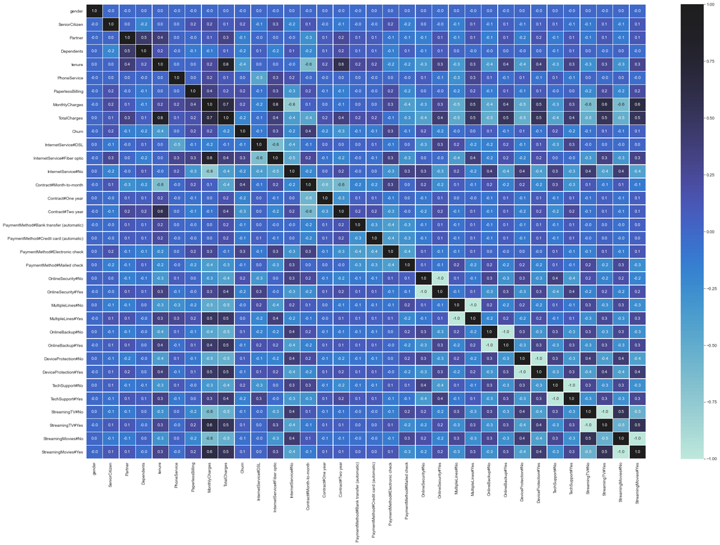

```python
plt.figure(figsize=(30,20))
sns.heatmap(df.corr(), annot=True,linewidths=.5, fmt= '.1f', center = 1 )
plt.show()
```

We can see that there is correlation between  
1. Tenure and TotalCharges  
2. Contract and Tenure  
3.Total Charges and Monthly Charges  
4.StreamingTV and MonthlyCharges etc.

We can also see some negative correlation among various different variables. so we plot another graph for a better understading.

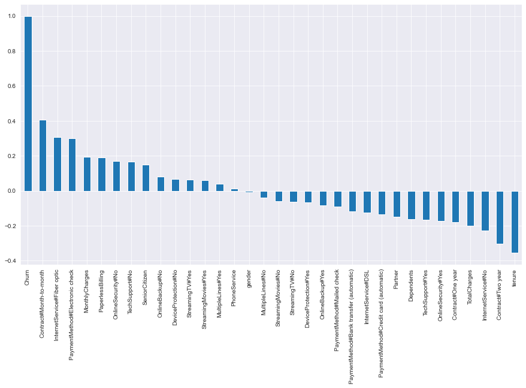

```python
#Get Correlation of "Churn" with other variables:
plt.figure(figsize=(15,8))
df.corr()['Churn'].sort_values(ascending = False).plot(kind='bar')
```

Month to month contracts, absence of online security and tech support seem to be positively correlated with churn.

Tenure, two year contracts seem to be negatively correlated with churn.

Services such as Online security, streaming TV, online backup, tech support, etc. without internet connection seem to be negatively related to churn.

Checking if all other variables have an impact on ChurnRate using hypothesis testing.

```python
cat_col=list(df.columns)
cat_col.remove('Churn')
for i in cat_col:
    crosstab=pd.crosstab(df['Churn'],df[i])
    chi,p_value,dof,expected=stats.chi2_contingency(crosstab)
    if p_value < 0.05:  # Setting our significance level at 5%
        print('Rejecting Null Hypothesis. \n There is significant difference in {} Feature for different category of target variable(Churn)'.format(i))
    else:
        print('Fail to Reject Null Hypothesis.\n There is no significant difference in {} Feature for different category of target variable(Churn)'.format(i))
```

```
Fail to Reject Null Hypothesis.
 There is no significant difference in customerID Feature for different category of target variable(Churn)
Fail to Reject Null Hypothesis.
 There is no significant difference in gender Feature for different category of target variable(Churn)
Rejecting Null Hypothesis.
 There is significant difference in SeniorCitizen Feature for different category of target variable(Churn)
Rejecting Null Hypothesis.
 There is significant difference in Partner Feature for different category of target variable(Churn)
Rejecting Null Hypothesis.
 There is significant difference in Dependents Feature for different category of target variable(Churn)
Rejecting Null Hypothesis.
 There is significant difference in tenure Feature for different category of target variable(Churn)
Fail to Reject Null Hypothesis.
 There is no significant difference in PhoneService Feature for different category of target variable(Churn)
Rejecting Null Hypothesis.
 There is significant difference in PaperlessBilling Feature for different category of target variable(Churn)
Rejecting Null Hypothesis.
 There is significant difference in MonthlyCharges Feature for different category of target variable(Churn)
Fail to Reject Null Hypothesis.
 There is no significant difference in TotalCharges Feature for different category of target variable(Churn)
Rejecting Null Hypothesis.
 There is significant difference in InternetService#DSL Feature for different category of target variable(Churn)
Rejecting Null Hypothesis.
 There is significant difference in InternetService#Fiber optic Feature for different category of target variable(Churn)
Rejecting Null Hypothesis.
 There is significant difference in InternetService#No Feature for different category of target variable(Churn)
Rejecting Null Hypothesis.
 There is significant difference in Contract#Month-to-month Feature for different category of target variable(Churn)
Rejecting Null Hypothesis.
 There is significant difference in Contract#One year Feature for different category of target variable(Churn)
Rejecting Null Hypothesis.
 There is significant difference in Contract#Two year Feature for different category of target variable(Churn)
Rejecting Null Hypothesis.
 There is significant difference in PaymentMethod#Bank transfer (automatic) Feature for different category of target variable(Churn)
Rejecting Null Hypothesis.
 There is significant difference in PaymentMethod#Credit card (automatic) Feature for different category of target variable(Churn)
Rejecting Null Hypothesis.
 There is significant difference in PaymentMethod#Electronic check Feature for different category of target variable(Churn)
Rejecting Null Hypothesis.
 There is significant difference in PaymentMethod#Mailed check Feature for different category of target variable(Churn)
```

[output cut: 13 more lines]

```
 There is significant difference in DeviceProtection#No Feature for different category of target variable(Churn)
Rejecting Null Hypothesis.
 There is significant difference in DeviceProtection#Yes Feature for different category of target variable(Churn)
Rejecting Null Hypothesis.
 There is significant difference in TechSupport#No Feature for different category of target variable(Churn)
Rejecting Null Hypothesis.
 There is significant difference in TechSupport#Yes Feature for different category of target variable(Churn)
Rejecting Null Hypothesis.
 There is significant difference in StreamingTV#No Feature for different category of target variable(Churn)
Rejecting Null Hypothesis.
 There is significant difference in StreamingTV#Yes Feature for different category of target variable(Churn)
Rejecting Null Hypothesis.
 There is significant difference in StreamingMovies#No Feature for different category of target variable(Churn)
Rejecting Null Hypothesis.
 There is significant difference in StreamingMovies#Yes Feature for different category of target variable(Churn)
```

We can see **CustomerId, Gender, PhoneService, and TotalCharges does not have significant difference in target variable** ie Churn.So we will drop these column before building model. But for general understanding purpose we will keep the Totalcharges cloumn.

```python
col2del = ["customerID","PhoneService","gender"]
df_rel = df.drop((col2del), axis = 1)
df_rel.info() #this is the database with the relevant columns for model building.
```

```
<class 'pandas.core.frame.DataFrame'>
RangeIndex: 7032 entries, 0 to 7031
Data columns (total 32 columns):
 #   Column                                   Non-Null Count  Dtype
---  ------                                   --------------  -----
 0   SeniorCitizen                            7032 non-null   int64
 1   Partner                                  7032 non-null   int64
 2   Dependents                               7032 non-null   int64
 3   tenure                                   7032 non-null   int64
 4   PaperlessBilling                         7032 non-null   int64
 5   MonthlyCharges                           7032 non-null   float64
 6   TotalCharges                             7032 non-null   float64
 7   Churn                                    7032 non-null   int64
 8   InternetService#DSL                      7032 non-null   uint8
 9   InternetService#Fiber optic              7032 non-null   uint8
```

[output cut: 24 more lines]

```python
df_rel.head()
```

|  | SeniorCitizen | Partner | Dependents | tenure | PaperlessBilling | MonthlyCharges | TotalCharges | Churn | InternetService#DSL | InternetService#Fiber optic | ... | OnlineBackup#No | OnlineBackup#Yes | DeviceProtection#No | DeviceProtection#Yes | TechSupport#No | TechSupport#Yes | StreamingTV#No | StreamingTV#Yes | StreamingMovies#No | StreamingMovies#Yes |
| --- | --- | --- | --- | --- | --- | --- | --- | --- | --- | --- | --- | --- | --- | --- | --- | --- | --- | --- | --- | --- | --- |
| 0 | 0 | 1 | 0 | 1 | 1 | 29.85 | 29.85 | 0 | 1 | 0 | ... | 0 | 1 | 1 | 0 | 1 | 0 | 1 | 0 | 1 | 0 |
| 1 | 0 | 0 | 0 | 34 | 0 | 56.95 | 1889.50 | 0 | 1 | 0 | ... | 1 | 0 | 0 | 1 | 1 | 0 | 1 | 0 | 1 | 0 |
| 2 | 0 | 0 | 0 | 2 | 1 | 53.85 | 108.15 | 1 | 1 | 0 | ... | 0 | 1 | 1 | 0 | 1 | 0 | 1 | 0 | 1 | 0 |
| 3 | 0 | 0 | 0 | 45 | 0 | 42.30 | 1840.75 | 0 | 1 | 0 | ... | 1 | 0 | 0 | 1 | 0 | 1 | 1 | 0 | 1 | 0 |
| 4 | 0 | 0 | 0 | 2 | 1 | 70.70 | 151.65 | 1 | 0 | 1 | ... | 1 | 0 | 1 | 0 | 1 | 0 | 1 | 0 | 1 | 0 |

5 rows × 32 columns

#### 3.Data analysis & visualisation:

• Perform detailed statistical analysis on the data.  
• Perform a detailed univariate, bivariate and multivariate analysis with appropriate detailed comments after each analysis.

```python
df.describe().T
```

|  | count | mean | std | min | 25% | 50% | 75% | max |
| --- | --- | --- | --- | --- | --- | --- | --- | --- |
| gender | 7032.0 | 0.504693 | 0.500014 | 0.00 | 0.0000 | 1.000 | 1.0000 | 1.00 |
| SeniorCitizen | 7032.0 | 0.162400 | 0.368844 | 0.00 | 0.0000 | 0.000 | 0.0000 | 1.00 |
| Partner | 7032.0 | 0.482509 | 0.499729 | 0.00 | 0.0000 | 0.000 | 1.0000 | 1.00 |
| Dependents | 7032.0 | 0.298493 | 0.457629 | 0.00 | 0.0000 | 0.000 | 1.0000 | 1.00 |
| tenure | 7032.0 | 32.421786 | 24.545260 | 1.00 | 9.0000 | 29.000 | 55.0000 | 72.00 |
| PhoneService | 7032.0 | 0.903299 | 0.295571 | 0.00 | 1.0000 | 1.000 | 1.0000 | 1.00 |
| PaperlessBilling | 7032.0 | 0.592719 | 0.491363 | 0.00 | 0.0000 | 1.000 | 1.0000 | 1.00 |
| MonthlyCharges | 7032.0 | 64.798208 | 30.085974 | 18.25 | 35.5875 | 70.350 | 89.8625 | 118.75 |
| TotalCharges | 7032.0 | 2283.300441 | 2266.771362 | 18.80 | 401.4500 | 1397.475 | 3794.7375 | 8684.80 |
| Churn | 7032.0 | 0.265785 | 0.441782 | 0.00 | 0.0000 | 0.000 | 1.0000 | 1.00 |
| InternetService#DSL | 7032.0 | 0.343572 | 0.474934 | 0.00 | 0.0000 | 0.000 | 1.0000 | 1.00 |
| InternetService#Fiber optic | 7032.0 | 0.440273 | 0.496455 | 0.00 | 0.0000 | 0.000 | 1.0000 | 1.00 |
| InternetService#No | 7032.0 | 0.216155 | 0.411650 | 0.00 | 0.0000 | 0.000 | 0.0000 | 1.00 |
| Contract#Month-to-month | 7032.0 | 0.551052 | 0.497422 | 0.00 | 0.0000 | 1.000 | 1.0000 | 1.00 |
| Contract#One year | 7032.0 | 0.209329 | 0.406858 | 0.00 | 0.0000 | 0.000 | 0.0000 | 1.00 |
| Contract#Two year | 7032.0 | 0.239619 | 0.426881 | 0.00 | 0.0000 | 0.000 | 0.0000 | 1.00 |
| PaymentMethod#Bank transfer (automatic) | 7032.0 | 0.219283 | 0.413790 | 0.00 | 0.0000 | 0.000 | 0.0000 | 1.00 |
| PaymentMethod#Credit card (automatic) | 7032.0 | 0.216297 | 0.411748 | 0.00 | 0.0000 | 0.000 | 0.0000 | 1.00 |
| PaymentMethod#Electronic check | 7032.0 | 0.336320 | 0.472483 | 0.00 | 0.0000 | 0.000 | 1.0000 | 1.00 |
| PaymentMethod#Mailed check | 7032.0 | 0.228100 | 0.419637 | 0.00 | 0.0000 | 0.000 | 0.0000 | 1.00 |
| OnlineSecurity#No | 7032.0 | 0.713453 | 0.452180 | 0.00 | 0.0000 | 1.000 | 1.0000 | 1.00 |
| OnlineSecurity#Yes | 7032.0 | 0.286547 | 0.452180 | 0.00 | 0.0000 | 0.000 | 1.0000 | 1.00 |
| MultipleLines#No | 7032.0 | 0.578072 | 0.493902 | 0.00 | 0.0000 | 1.000 | 1.0000 | 1.00 |
| MultipleLines#Yes | 7032.0 | 0.421928 | 0.493902 | 0.00 | 0.0000 | 0.000 | 1.0000 | 1.00 |
| OnlineBackup#No | 7032.0 | 0.655148 | 0.475354 | 0.00 | 0.0000 | 1.000 | 1.0000 | 1.00 |
| OnlineBackup#Yes | 7032.0 | 0.344852 | 0.475354 | 0.00 | 0.0000 | 0.000 | 1.0000 | 1.00 |
| DeviceProtection#No | 7032.0 | 0.656143 | 0.475028 | 0.00 | 0.0000 | 1.000 | 1.0000 | 1.00 |
| DeviceProtection#Yes | 7032.0 | 0.343857 | 0.475028 | 0.00 | 0.0000 | 0.000 | 1.0000 | 1.00 |
| TechSupport#No | 7032.0 | 0.709898 | 0.453842 | 0.00 | 0.0000 | 1.000 | 1.0000 | 1.00 |
| TechSupport#Yes | 7032.0 | 0.290102 | 0.453842 | 0.00 | 0.0000 | 0.000 | 1.0000 | 1.00 |
| StreamingTV#No | 7032.0 | 0.615614 | 0.486484 | 0.00 | 0.0000 | 1.000 | 1.0000 | 1.00 |
| StreamingTV#Yes | 7032.0 | 0.384386 | 0.486484 | 0.00 | 0.0000 | 0.000 | 1.0000 | 1.00 |
| StreamingMovies#No | 7032.0 | 0.611633 | 0.487414 | 0.00 | 0.0000 | 1.000 | 1.0000 | 1.00 |
| StreamingMovies#Yes | 7032.0 | 0.388367 | 0.487414 | 0.00 | 0.0000 | 0.000 | 1.0000 | 1.00 |

All statistical values seem to be relevant and there are no outliers or concerns related to the data.

Also, we can see that the Total Charges = Monthly Charges * Tenure.

#### Univariate Analysis

**Distribution and outlier analysis of numerical variables**

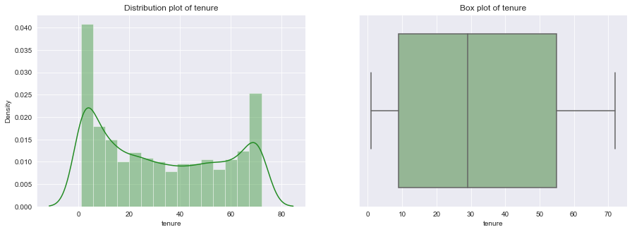

```
Total Number of outliers in tenure 0
```

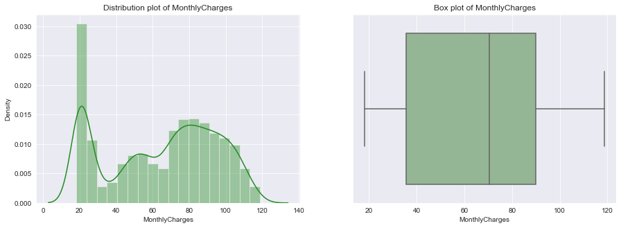

```
Total Number of outliers in MonthlyCharges 0
```

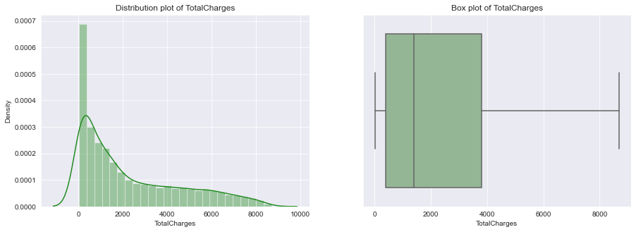

```
Total Number of outliers in TotalCharges 0
```

```python
col2 = ['tenure','MonthlyCharges','TotalCharges']
for i in col2:
    f, axes = plt.subplots(1, 2, figsize=(15,5))
    sns.distplot(df_graph[i],  ax=axes[0],color = 'forestgreen')
    sns.boxplot(x = i, data=df_graph,  orient='h' , ax=axes[1],color = 'darkseagreen')
    axes[0].set_title('Distribution plot of {}'.format(i))
    axes[1].set_title('Box plot of {}'.format(i))
    plt.show()
    #checking count of outliers.
    q25,q75=np.percentile(df_graph[i],25),np.percentile(df_graph[i],75)
    IQR=q75-q25
    Threshold=IQR*1.5
    lower,upper=q25-Threshold,q75+Threshold
    Outliers=[j for j in df_graph[i] if j < lower or j > upper]
    b=len(Outliers)
    print('Total Number of outliers in {} {}'.format(i,b))
```

**Tenure**

We can see that the distribution is not normal.Bi-Modal distribution (having 2 peaks) which means data is concentrated across two different groups.

There are no outliers in this column.

Therer are a lot customers in 69-72 months range. They are the loyal customers.

**Monthly Charges**

The distrbution is not normal.

There are no outliers in this column.

Customers whose monthly charges are more when considered less than 30. but most number of customer lies between 70-100.

**Total Charges**

The distrbution is not normal.The data is positively skewed.

There are no outliers in this column.

Majority of customers pay close to 1000 units.

Customers have paid around 9000 units too.

#### Distribution of categorical variables

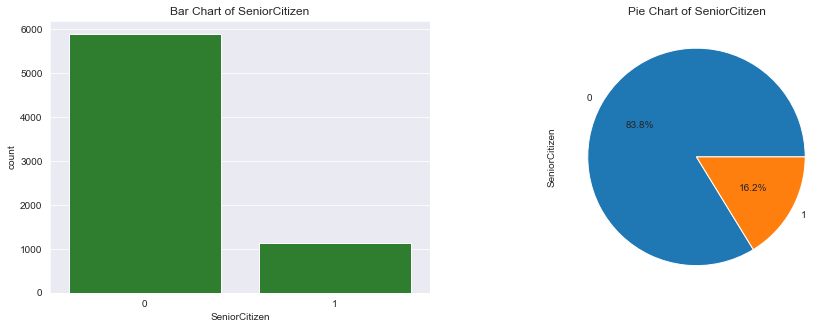

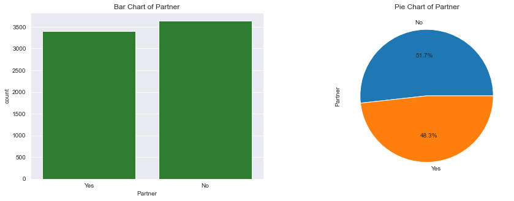

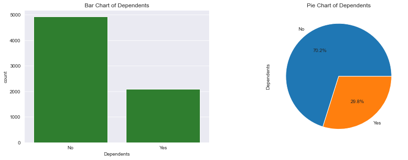

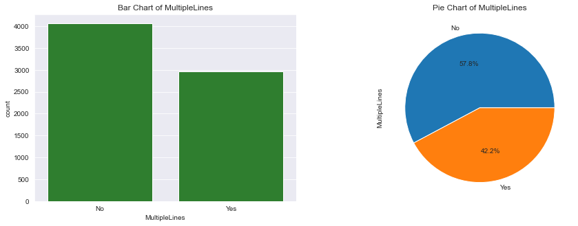

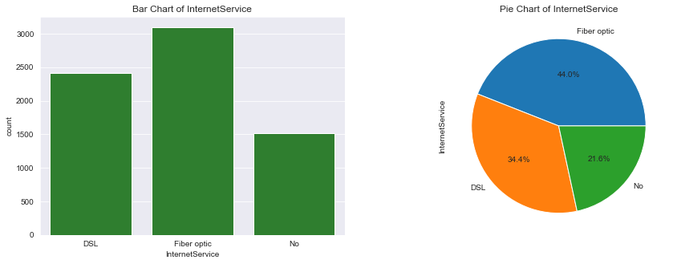

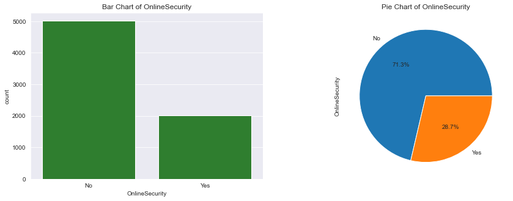

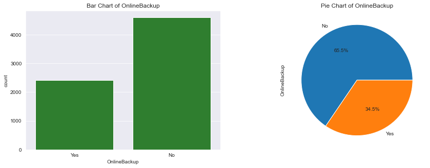

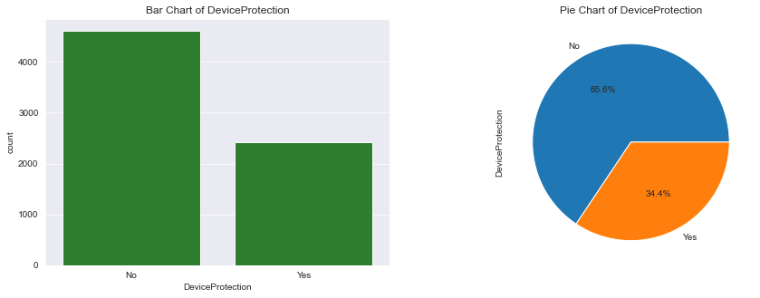

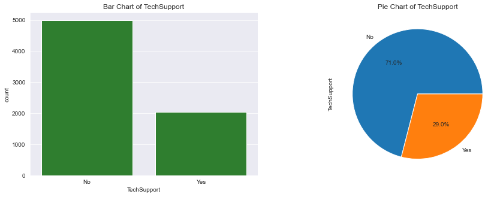

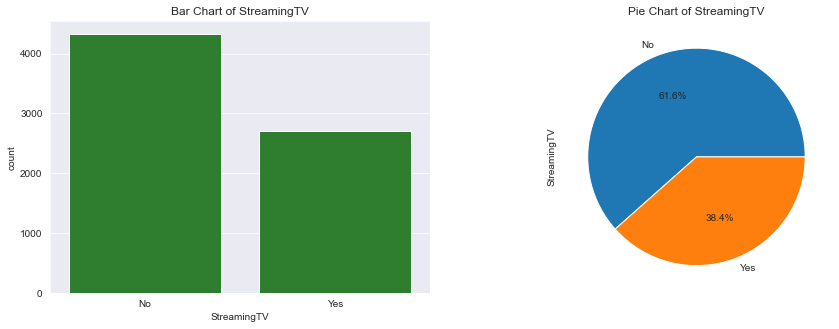

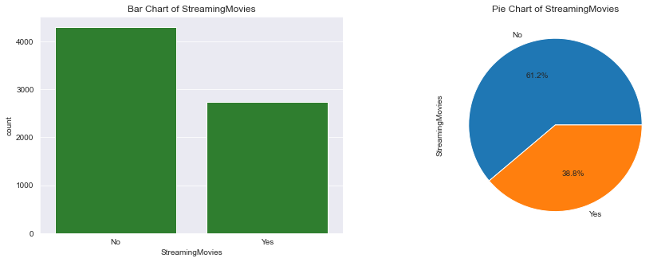

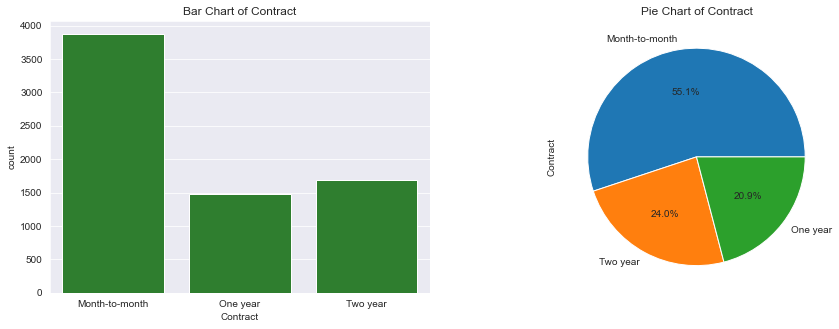

[3 more figures not shown]

```python
col3 = ['SeniorCitizen', 'Partner', 'Dependents', 'MultipleLines',
       'InternetService', 'OnlineSecurity', 'OnlineBackup', 'DeviceProtection',
       'TechSupport', 'StreamingTV', 'StreamingMovies', 'Contract',
       'PaperlessBilling', 'PaymentMethod', 'Churn']
for i in col3:
    f, axes = plt.subplots(1, 2, figsize=(15,5))
    sns.countplot(df_graph[i],  ax=axes[0],color = 'forestgreen')
    df_graph[i].value_counts().plot.pie(autopct='%1.1f%%',ax=axes[1])
    axes[0].set_title('Bar Chart of {}'.format(i))
    axes[1].set_title('Pie Chart of {}'.format(i))
    plt.show()
```

We have almost equal genders in our dataset

Almost 50% have partners

Around 30% have dependants

Around 40% customers have multiple lines

People prefer Fiber Optics over DSL for Internet

Around 30% have taken online security.Majority of Customer don't have Online security or backup

lose 35% prefer device protection

Majority of Customer don't have Tech Support

Around 37% have registered for Streaming TV & MOvie

Contract - Majority of customers are subscribed for Month to Month contract (55%)

Majority of customers have opted Paperless billing

Target Variable - "Churn" - We have unbalanced distribution (Yes - Approx 1800 ; No - Approx 5000). So Churn positive is 25% (Approx).

#### Bi-variate Analysis

**Churn VS Tenure & MonthlyCharges**

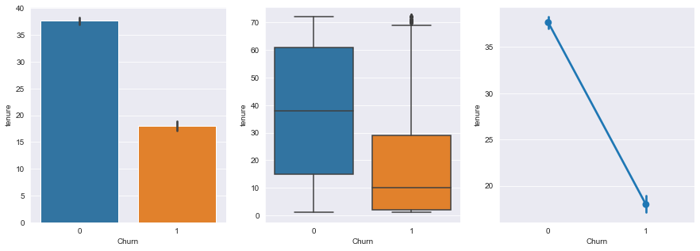

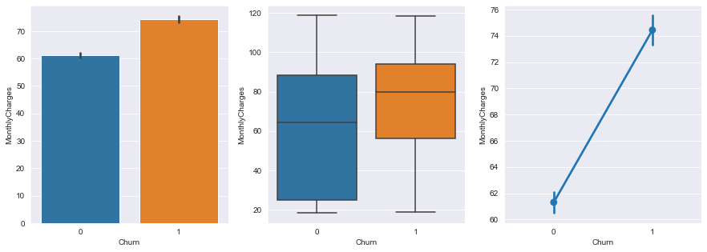

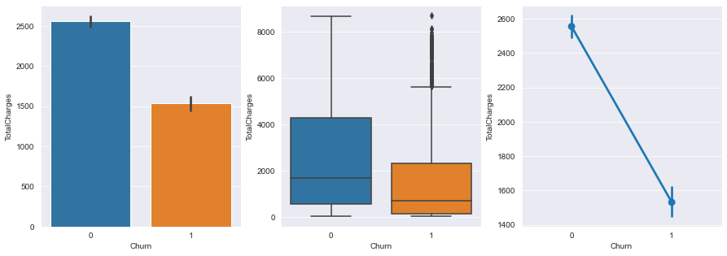

```python
col2 = ['tenure','MonthlyCharges','TotalCharges']
for i in col2:
    f, axes = plt.subplots(1, 3, figsize=(15,5))
    plt.figure(figsize=(15,7))
    sns.barplot(x='Churn', y=df_graph[i], data = df_rel ,ax=axes[0])
    sns.boxplot(x='Churn', y=df_graph[i], data = df_rel ,ax=axes[1])
    sns.pointplot(x='Churn', y=df_graph[i], data = df_rel,ax=axes[2])
    plt.show()
```

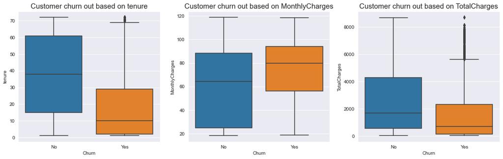

```python
fig, ax = plt.subplots(1, 3)
fig.set_figheight(5)
fig.set_figwidth(18)
sns.boxplot(x='Churn', y ='tenure', data=df_graph, ax=ax[0])
sns.boxplot(x='Churn', y ='MonthlyCharges', data= df_graph, ax=ax[1])
sns.boxplot(x='Churn', y='TotalCharges',data=df_graph, ax=ax[2])
ax[0].set_title("Customer churn out based on tenure",fontsize=15)
ax[1].set_title('Customer churn out based on MonthlyCharges',fontsize=15)
ax[2].set_title('Customer churn out based on TotalCharges',fontsize=15)
plt.show()
```

**Tenure**

We can see that customers who tend to churn have a lower tenure.

There are outliers in the number of customers who churn based in the tenure.

**Mothly Charges**

Customers who have higher monthly Charges tend to leave the operator.

There is a mojor difference in the average of monthlyCharges for customers who churn or not.

Highest customer on 20-29 monthly charges.

Lowest customer on 30-39 monthly charges.

Highest customer did churn on 70-79 monthly charges.

Highest customer did not churn on 20-29 monthly charges.

The customer did churn average is on 70-79 monthly charges (74.4) while median is on 80-89 monthly charges (80.0).

The customer did not churn average is on 60-69 monthly charges (61.3) while median is on is on 60-69 monthly charges (64.0).

Customers opting for less tenure are more propable to churn.

Customers whose monthly charges are more propable to churn.

Customers who paying total charges less than 2000 are more probable to churn

**Churn by Contract Type**

```python
import matplotlib.ticker as mtick
```

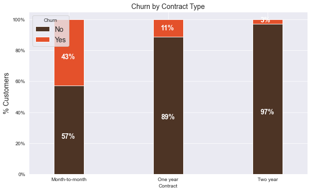

```python
colors = ['#4D3425','#E4512B']
contract_churn = df_graph.groupby(['Contract','Churn']).size().unstack()

ax = (contract_churn.T*100.0 / contract_churn.T.sum()).T.plot(kind='bar',width = 0.3,stacked = True,rot = 0, figsize = (10,6),color = colors)
ax.yaxis.set_major_formatter(mtick.PercentFormatter())
ax.legend(loc='best',prop={'size':14},title = 'Churn')
ax.set_ylabel('% Customers',size = 14)
ax.set_title('Churn by Contract Type',size = 14)

# Code to add the data labels on the stacked bar chart
for p in ax.patches:
    width, height = p.get_width(), p.get_height()
    x, y = p.get_xy()
    ax.annotate('{:.0f}%'.format(height), (p.get_x()+.25*width, p.get_y()+.4*height),color = 'white',weight = 'bold',size = 14)
```

Similar to what we saw in the correlation plot, the customers who have a month to month contract have a very high churn rate.

**Churn by Seniority**

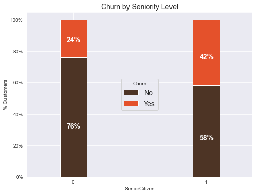

```python
colors = ['#4D3425','#E4512B']
seniority_churn = df_graph.groupby(['SeniorCitizen','Churn']).size().unstack()

ax = (seniority_churn.T*100.0 / seniority_churn.T.sum()).T.plot(kind='bar',width = 0.2,stacked = True,rot = 0, figsize = (8,6),color = colors)
ax.yaxis.set_major_formatter(mtick.PercentFormatter())
ax.legend(loc='center',prop={'size':14},title = 'Churn')
ax.set_ylabel('% Customers')
ax.set_title('Churn by Seniority Level',size = 14)
# Code to add the data labels on the stacked bar chart
for p in ax.patches:
    width, height = p.get_width(), p.get_height()
    x, y = p.get_xy()
    ax.annotate('{:.0f}%'.format(height), (p.get_x()+.25*width, p.get_y()+.4*height),color = 'white',weight = 'bold',size =14)
```

Senior Citizens have almost double the churn rate than younger population.

```python
columns = ['gender', 'SeniorCitizen', 'Partner', 'Dependents',
       'PhoneService', 'MultipleLines', 'InternetService',
       'OnlineSecurity', 'OnlineBackup', 'DeviceProtection', 'TechSupport',
       'StreamingTV', 'StreamingMovies', 'Contract', 'PaperlessBilling',
       'PaymentMethod',]
```

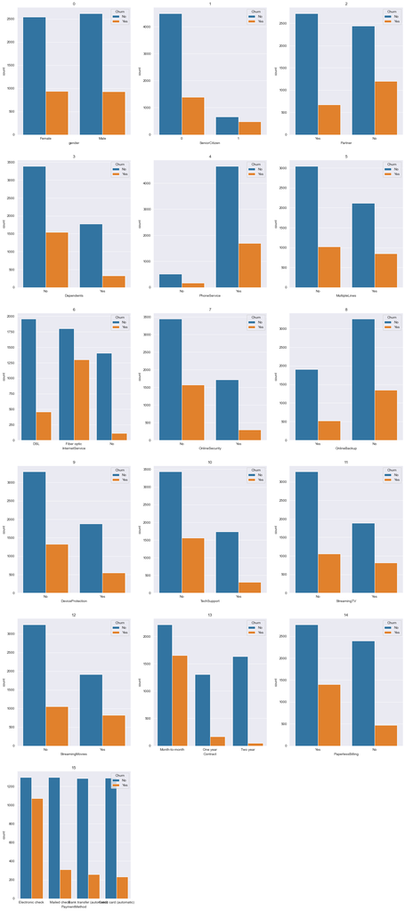

```python
import copy

a = 10  # number of rows
b = 3  # number of columns
c = 1  # initialize plot counter

fig = plt.figure(figsize=(20,80))

for i in range(len(columns)):
    xx = copy.deepcopy(columns)
    plt.subplot(a, b, c)
    plt.title('{}'.format(i))
    plt.xlabel(xx[i])
    sns.countplot(x=xx[i], hue="Churn", data=df_graph)
    c = c + 1

plt.show()
```

We can observe gender churn out are same in male and female.

Customers churn out is more who dont have partner and dependents, having phone service, internet service with fiber optics, no online security, no online backup, no device protection, no tech support, streaming tv, streaming movies, having month-to-month contract, paperlessbilling, having electronic check in payment method.

'Partner' : Customer with partner have lower chance of leaving

'Dependents' :Customer with dependants have lower chance of leaving.

'InternetService' : Customer with Fiber Optic Interner Service have higher chances of leaving.

'DeviceProtection' : Customers without device protection have likely higher chances of leaving.

'TechSupport' - Customer not opting for TechSupport have higher chances of leaving.

'Contract' - Month to Month customers have likely higher chances to leave.

'PaperlessBilling' - Customers with paperless billing have higher chances of leaving.

'PaymentMethod' - People paying with electronic check have higher chances of leaving.

**Multivariate Analysis**

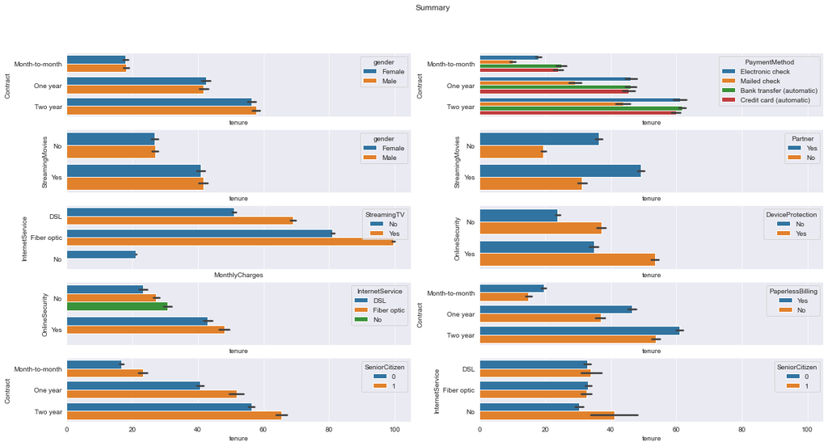

```python
fig, axes = plt.subplots(5, 2, sharex=True, figsize=(20, 10))
fig.suptitle('Summary')
sns.barplot(ax=axes[0, 0], x="tenure", y="Contract", hue="gender", data=df_graph,orient="h")
sns.barplot(ax=axes[0, 1], x="tenure", y="Contract", hue="PaymentMethod", data=df_graph,orient="h")
sns.barplot(ax=axes[1, 0], x="tenure", y="StreamingMovies", hue="gender", data=df_graph,orient="h")
sns.barplot(ax=axes[1, 1], x="tenure", y="StreamingMovies", hue="Partner", data=df_graph,orient="h")
sns.barplot(ax=axes[2, 0], x="MonthlyCharges", y="InternetService", hue="StreamingTV", data=df_graph,orient="h")
sns.barplot(ax=axes[2, 1], x="tenure", y="OnlineSecurity", hue="DeviceProtection", data=df_graph,orient="h")
sns.barplot(ax=axes[3, 0], x="tenure", y="OnlineSecurity", hue="InternetService", data=df_graph,orient="h")
sns.barplot(ax=axes[3, 1], x="tenure", y="Contract", hue="PaperlessBilling", data=df_graph,orient="h")
sns.barplot(ax=axes[4, 0], x="tenure", y="Contract", hue="SeniorCitizen", data=df_graph,orient="h")
sns.barplot(ax=axes[4, 1], x="tenure", y="InternetService", hue="SeniorCitizen", data=df_graph,orient="h")
```

#### 4. Data pre-processing

• Segregate predictors vs target attributes  
• Check for target balancing and fix it if found imbalanced.  
• Perform train-test split.  
• Check if the train and test data have similar statistical characteristics when compared with original data.

**Segregate predictors vs target attributes**

```python
X= df_rel.drop(['Churn'], axis = 1) #Predictor attributes
X.head()
```

|  | SeniorCitizen | Partner | Dependents | tenure | PaperlessBilling | MonthlyCharges | TotalCharges | InternetService#DSL | InternetService#Fiber optic | InternetService#No | ... | OnlineBackup#No | OnlineBackup#Yes | DeviceProtection#No | DeviceProtection#Yes | TechSupport#No | TechSupport#Yes | StreamingTV#No | StreamingTV#Yes | StreamingMovies#No | StreamingMovies#Yes |
| --- | --- | --- | --- | --- | --- | --- | --- | --- | --- | --- | --- | --- | --- | --- | --- | --- | --- | --- | --- | --- | --- |
| 0 | 0 | 1 | 0 | 1 | 1 | 29.85 | 29.85 | 1 | 0 | 0 | ... | 0 | 1 | 1 | 0 | 1 | 0 | 1 | 0 | 1 | 0 |
| 1 | 0 | 0 | 0 | 34 | 0 | 56.95 | 1889.50 | 1 | 0 | 0 | ... | 1 | 0 | 0 | 1 | 1 | 0 | 1 | 0 | 1 | 0 |
| 2 | 0 | 0 | 0 | 2 | 1 | 53.85 | 108.15 | 1 | 0 | 0 | ... | 0 | 1 | 1 | 0 | 1 | 0 | 1 | 0 | 1 | 0 |
| 3 | 0 | 0 | 0 | 45 | 0 | 42.30 | 1840.75 | 1 | 0 | 0 | ... | 1 | 0 | 0 | 1 | 0 | 1 | 1 | 0 | 1 | 0 |
| 4 | 0 | 0 | 0 | 2 | 1 | 70.70 | 151.65 | 0 | 1 | 0 | ... | 1 | 0 | 1 | 0 | 1 | 0 | 1 | 0 | 1 | 0 |

5 rows × 31 columns

```python
y = df_rel['Churn'] #Target Attribute
y.head()
```

```
0    0
1    0
2    1
3    0
4    1
Name: Churn, dtype: int64
```

```python
print('Shape of X: {}'.format(X.shape))
print('Shape of y: {}'.format(y.shape))
```

```
Shape of X: (7032, 31)
Shape of y: (7032,)
```

**Check for target balancing and fix it if found imbalanced.**

```python
count_no_churn = (df_rel['Churn'] == 0).sum()
print("Number of customers who didn't churn:",count_no_churn)
count_yes_churn = (df_rel['Churn']==1).sum()
print("Number of customers who churnes:",count_yes_churn)
```

```
Number of customers who didn't churn: 5163
Number of customers who churnes: 1869
```

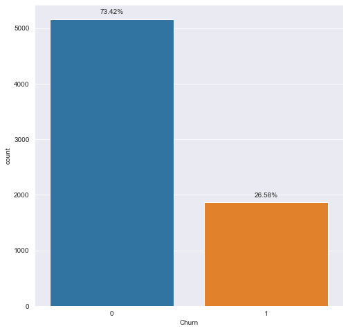

```python
fig, ax = plt.subplots(figsize=(20,8))
width = len(df_rel['Churn'].unique())+6
fig.set_size_inches(width , 8)
ax=sns.countplot(data = df_rel, x= 'Churn')
for p in ax.patches:
    ax.annotate(str((np.round(p.get_height()/len(df)*100,decimals=2)))+'%', (p.get_x()+p.get_width()/2., p.get_height()), ha='center', va='center', xytext=(0, 10), textcoords='offset points')
```

Standardization (Scaling) for numerical variables

```python
from sklearn.preprocessing import StandardScaler
cols_to_scale = ["MonthlyCharges","TotalCharges","tenure"]
scaler=StandardScaler()
X[cols_to_scale]=scaler.fit_transform(X[cols_to_scale])
X.sample(5)
```

|  | SeniorCitizen | Partner | Dependents | tenure | PaperlessBilling | MonthlyCharges | TotalCharges | InternetService#DSL | InternetService#Fiber optic | InternetService#No | ... | OnlineBackup#No | OnlineBackup#Yes | DeviceProtection#No | DeviceProtection#Yes | TechSupport#No | TechSupport#Yes | StreamingTV#No | StreamingTV#Yes | StreamingMovies#No | StreamingMovies#Yes |
| --- | --- | --- | --- | --- | --- | --- | --- | --- | --- | --- | --- | --- | --- | --- | --- | --- | --- | --- | --- | --- | --- |
| 3836 | 1 | 1 | 0 | -1.280248 | 0 | 0.201164 | -0.976105 | 0 | 1 | 0 | ... | 1 | 0 | 1 | 0 | 1 | 0 | 1 | 0 | 1 | 0 |
| 4622 | 0 | 0 | 0 | -0.424625 | 0 | 0.008370 | -0.377546 | 1 | 0 | 0 | ... | 0 | 1 | 0 | 1 | 1 | 0 | 1 | 0 | 1 | 0 |
| 5345 | 0 | 0 | 1 | -1.280248 | 1 | 0.816112 | -0.967943 | 0 | 1 | 0 | ... | 1 | 0 | 1 | 0 | 1 | 0 | 0 | 1 | 0 | 1 |
| 1888 | 0 | 0 | 1 | -0.669089 | 1 | 0.142993 | -0.529249 | 1 | 0 | 0 | ... | 0 | 1 | 1 | 0 | 1 | 0 | 1 | 0 | 0 | 1 |
| 2731 | 1 | 1 | 0 | 1.123646 | 0 | 0.819436 | 1.328548 | 0 | 1 | 0 | ... | 0 | 1 | 1 | 0 | 1 | 0 | 1 | 0 | 0 | 1 |

5 rows × 31 columns

**Perform train-test split.**

```python
from sklearn.model_selection import train_test_split
X_train, X_test, y_train, y_test = train_test_split(X, y, test_size=0.3, random_state=0)

print(" X_train shape ", X_train.shape)
print(" y_train shape ", y_train.shape)
print(" X_test shape ", X_test.shape)
print("y_test shape ", y_test.shape)
```

```
 X_train shape  (4922, 31)
 y_train shape  (4922,)
 X_test shape  (2110, 31)
y_test shape  (2110,)
```

**Fixing Target Imbalace using SMOTE**

```python
from imblearn.over_sampling import RandomOverSampler
from imblearn.over_sampling import SMOTE
```

```python
X.info()
```

```
<class 'pandas.core.frame.DataFrame'>
RangeIndex: 7032 entries, 0 to 7031
Data columns (total 31 columns):
 #   Column                                   Non-Null Count  Dtype
---  ------                                   --------------  -----
 0   SeniorCitizen                            7032 non-null   int64
 1   Partner                                  7032 non-null   int64
 2   Dependents                               7032 non-null   int64
 3   tenure                                   7032 non-null   float64
 4   PaperlessBilling                         7032 non-null   int64
 5   MonthlyCharges                           7032 non-null   float64
 6   TotalCharges                             7032 non-null   float64
 7   InternetService#DSL                      7032 non-null   uint8
 8   InternetService#Fiber optic              7032 non-null   uint8
 9   InternetService#No                       7032 non-null   uint8
```

[output cut: 23 more lines]

```python
sm = SMOTE(random_state=0)
X_train_res, y_train_res = sm.fit_resample(X_train, y_train)

print('After OverSampling, the shape of train_X: {}'.format(X_train_res.shape))
print('After OverSampling, the shape of train_y: {}'.format(y_train_res.shape))
```

```
After OverSampling, the shape of train_X: (7216, 31)
After OverSampling, the shape of train_y: (7216,)
```

Now we have balanced data!

**Check if the train and test data have similar statistical characteristics when compared with original data.**  
To check similar charecteristics, we will consider one sample from train data and another similar sample from test and compare them separetly with population of Original data.  
To do this we will do hypopthesis testing using one sample Z-Test.  
Lets consider MonthlyCharges attribute as a sample (its having positive impact and its numeric) to check similar charecteristics

```python
Original = X['MonthlyCharges'] #Population from orignal data
mu = Original.mean()
sigma = Original.std(ddof=0)
print("mu: ", mu, ", sigma:", sigma)
```

```
mu:  9.652877662909851e-17 , sigma: 0.9999999999999967
```

```python
train = X_train['MonthlyCharges'] #Sample from Train data
X_bar = train.mean()
n= X_train['MonthlyCharges'].size
print("X_Bar: ", X_bar, ", n:", n)
```

```
X_Bar:  0.0021922976234097164 , n: 4922
```

Train and Test data is having similar charecteristics with Original data  
H0: The sample from train or test data comes from the original population, x_bar = μ.  
HA: The sample from train or test data not comes from the original population, x_bar != (not equal) μ.

```python
z_critical = 1.96 # alpha level of 0.05 and two-tailed test
SE = sigma/np.sqrt(n)
z_stat = (X_bar - mu)/SE
print(z_stat)
```

```
0.15380495172850617
```

```python
test = X_test['MonthlyCharges']
X_bar_Test = test.mean()
n2= X_test['MonthlyCharges'].size
print("X_Bar: ", X_bar_Test, ", n:", n2)
```

```
X_Bar:  -0.005113975783138369 , n: 2110
```

```python
z_critical = 1.96 # alpha level of 0.05 and two-tailed test
SE = sigma/np.sqrt(n2)
z_stat = (X_bar_Test - mu)/SE
print(z_stat)
```

```
-0.23490912910147121
```

Since z_stat is less than z_critical we accept the null hypothesis and reject the althernative. Statistically, we say the train and test sample mean is no different than the population mean and thus the train and test sample is drawn from the population.

We can conclude that test and train have similar characteristics when compared with original data.

#### 5.Model Training, Testing and Tuning

• Train and test all ensemble models taught in the learning module.  
• Suggestion: Use standard ensembles available. Also you can design your own ensemble technique using weak classifiers.  
• Display the classification accuracies for train and test data.  
• Apply all the possible tuning techniques to train the best model for the given data.  
• Suggestion: Use all possible hyper parameter combinations to extract the best accuracies.  
• Display and compare all the models designed with their train and test accuracies.  
• Select the final best trained model along with your detailed comments for selecting this model.  
• Pickle the selected model for future use.

```python
from sklearn.neighbors import KNeighborsClassifier
from sklearn.linear_model import LogisticRegression
from sklearn.svm import SVC
from sklearn.tree import DecisionTreeClassifier
from sklearn.ensemble import RandomForestClassifier
from sklearn.model_selection import GridSearchCV
from sklearn.ensemble import AdaBoostClassifier
from sklearn.ensemble import BaggingClassifier
from sklearn.ensemble import GradientBoostingClassifier
from catboost import CatBoostClassifier
from xgboost import XGBClassifier
from lightgbm import LGBMClassifier
from sklearn.linear_model import RidgeClassifier
from sklearn.naive_bayes import GaussianNB
from sklearn.naive_bayes import BernoulliNB
from sklearn.model_selection import GridSearchCV, cross_val_score, train_test_split, GridSearchCV, RandomizedSearchCV,StratifiedKFold
from sklearn.metrics import accuracy_score,confusion_matrix,roc_auc_score,ConfusionMatrixDisplay,precision_score,recall_score,f1_score,classification_report,roc_curve,plot_roc_curve,auc,precision_recall_curve,plot_precision_recall_curve,average_precision_score
from sklearn.ensemble import VotingClassifier
```

```python
#Ensemble Algorithms
models = []
models.append(['XGBClassifier',XGBClassifier(learning_rate=0.1,objective='binary:logistic',random_state=0,eval_metric='mlogloss')])
models.append(['RandomForest',RandomForestClassifier(random_state=0)])
models.append(['AdaBoostClassifier',AdaBoostClassifier()])
models.append(['GBClassifier',GradientBoostingClassifier(n_estimators = 50, learning_rate = 0.1, random_state=0)])
models.append(['LGBMClassifier',LGBMClassifier(random_state=0)])
models.append(['CatBoostClassifier',CatBoostClassifier(learning_rate=0.1,loss_function= 'Logloss', eval_metric='AUC',random_state=0)])
models.append(['BaggingClassifier', BaggingClassifier(n_estimators=50, max_samples= .7, bootstrap=True, oob_score=True, random_state=22)])

# For hybrid model preparation
Hybrid = []
Hybrid.append(['RidgeClassifier',RidgeClassifier()])
Hybrid.append(['Logistic Regression',LogisticRegression(random_state=0)])
Hybrid.append(['SVM',SVC(random_state=0)])
Hybrid.append(['KNeigbors',KNeighborsClassifier()])
Hybrid.append(['GaussianNB',GaussianNB()])
Hybrid.append(['BernoulliNB',BernoulliNB()])
Hybrid.append(['DecisionTree',DecisionTreeClassifier(random_state=0)])
```

```python
lst_1 = []
for m in range(len(models)):
    lst_2 = []
    model = models[m][1]
    model.fit(X_train_res,y_train_res)
    y_pred = model.predict(X_test)
    y_train_pred = model.predict(X_train_res)
    cm = confusion_matrix(y_test,y_pred)
    accuracies = cross_val_score(estimator= model, X = X_train_res,y = y_train_res, cv=10)

# k-fOLD Validation
    roc = roc_auc_score(y_test,y_pred)
    precision = precision_score(y_test,y_pred)
    recall = recall_score(y_test,y_pred)
    f1 = f1_score(y_test,y_pred)
    print(models[m][0],':')
    print(cm)
    print('')
    print('Train Accuracy Score: ',accuracy_score(y_train_res,y_train_pred))
    print('')
    print('Test Accuracy Score: ',accuracy_score(y_test,y_pred))
    print('')
    print('K-Fold Validation Mean Accuracy: {:.2f} %'.format(accuracies.mean()*100))
    print('')
    print('Standard Deviation: {:.2f} %'.format(accuracies.std()*100))
    print('')
    print('ROC AUC Score: {:.2f} %'.format(roc))
    print('')
    print('Precision: {:.2f} %'.format(precision))
    print('')
    print('Recall: {:.2f} %'.format(recall))
    print('')
    print('F1 Score: {:.2f} %'.format(f1))
    print('')
    print(classification_report(y_test, y_pred))
    print('-'*40)
    print('')
    lst_2.append(models[m][0])
    lst_2.append(accuracy_score(y_train_res,y_train_pred)*100)
    lst_2.append(accuracy_score(y_test,y_pred)*100)
    lst_2.append(accuracies.mean()*100)
    lst_2.append(accuracies.std()*100)
    lst_2.append(roc)
    lst_2.append(precision)
    lst_2.append(recall)
    lst_2.append(f1)
    lst_1.append(lst_2)
```

```
XGBClassifier :
[[1272  283]
 [ 177  378]]

Train Accuracy Score:  0.8941241685144125

Test Accuracy Score:  0.7819905213270142

K-Fold Validation Mean Accuracy: 83.73 %

Standard Deviation: 6.84 %

ROC AUC Score: 0.75 %

Precision: 0.57 %

Recall: 0.68 %

F1 Score: 0.62 %

              precision    recall  f1-score   support

           0       0.88      0.82      0.85      1555
           1       0.57      0.68      0.62       555

    accuracy                           0.78      2110
   macro avg       0.72      0.75      0.73      2110
weighted avg       0.80      0.78      0.79      2110

----------------------------------------

RandomForest :
[[1289  266]
 [ 210  345]]

Train Accuracy Score:  0.9983370288248337

Test Accuracy Score:  0.7744075829383886

K-Fold Validation Mean Accuracy: 85.17 %
```

[output cut: 11161 more lines]

```

Recall: 0.59 %

F1 Score: 0.57 %

              precision    recall  f1-score   support

           0       0.85      0.82      0.84      1555
           1       0.55      0.59      0.57       555

    accuracy                           0.76      2110
   macro avg       0.70      0.71      0.70      2110
weighted avg       0.77      0.76      0.77      2110

----------------------------------------
```

**Creating Hybrid model using other algorithms**

```python
#Hybrid
lst_3 = []
Hybrid_ensemble = VotingClassifier(Hybrid)
Hybrid_ensemble.fit(X_train_res,y_train_res)
y_pred_Hyb = Hybrid_ensemble.predict(X_test)
y_train_pred_Hyb = Hybrid_ensemble.predict(X_train_res)
cm = confusion_matrix(y_test,y_pred_Hyb)
accuracies = cross_val_score(estimator= Hybrid_ensemble, X = X_train_res,y = y_train_res, cv=10)

# k-fOLD Validation
roc = roc_auc_score(y_test,y_pred_Hyb)
precision = precision_score(y_test,y_pred_Hyb)
recall = recall_score(y_test,y_pred_Hyb)
f1 = f1_score(y_test,y_pred_Hyb)
print('Hybrid_Model')
print(cm)
print('')
print('Train Accuracy Score: ',accuracy_score(y_train_res,y_train_pred_Hyb))
print('')
print('Test Accuracy Score: ',accuracy_score(y_test,y_pred_Hyb))
print('')
print('K-Fold Validation Mean Accuracy: {:.2f} %'.format(accuracies.mean()*100))
print('')
print('Standard Deviation: {:.2f} %'.format(accuracies.std()*100))
print('')
print('ROC AUC Score: {:.2f} %'.format(roc))
print('')
print('Precision: {:.2f} %'.format(precision))
print('')
print('Recall: {:.2f} %'.format(recall))
print('')
print('F1 Score: {:.2f} %'.format(f1))
print('-'*40)
print('')
lst_3.append('Hybrid_model')
lst_3.append(accuracy_score(y_train_res,y_train_pred_Hyb)*100)
lst_3.append(accuracy_score(y_test,y_pred_Hyb)*100)
lst_3.append(accuracies.mean()*100)
lst_3.append(accuracies.std()*100)
lst_3.append(roc)
lst_3.append(precision)
lst_3.append(recall)
lst_3.append(f1)
lst_1.append(lst_3)
#final =pd.concat([lst_1,lst_3], axis=1)
```

```
Hybrid_Model
[[1214  341]
 [ 155  400]]

Train Accuracy Score:  0.8435421286031042

Test Accuracy Score:  0.7649289099526067

K-Fold Validation Mean Accuracy: 82.78 %

Standard Deviation: 4.21 %

ROC AUC Score: 0.75 %

Precision: 0.54 %

Recall: 0.72 %

F1 Score: 0.62 %
----------------------------------------
```

**Display the classification accuracies for train and test data.**

```python
df2 = pd.DataFrame(lst_1,columns=['Model','Train_Accuracy','Test_Accuracy','K-Fold Mean Accuracy','Std.Deviation','ROC_AUC','Precision','Recall','F1 Score'])
df2.sort_values(by=['Recall','F1 Score'],inplace=True,ascending=False)
df2
```

|  | Model | Train_Accuracy | Test_Accuracy | K-Fold Mean Accuracy | Std.Deviation | ROC_AUC | Precision | Recall | F1 Score |
| --- | --- | --- | --- | --- | --- | --- | --- | --- | --- |
| 3 | GBClassifier | 82.220067 | 76.161137 | 80.766383 | 3.539172 | 0.761788 | 0.532746 | 0.762162 | 0.627131 |
| 2 | AdaBoostClassifier | 80.626386 | 75.355450 | 79.976314 | 2.884481 | 0.748211 | 0.522350 | 0.736937 | 0.611360 |
| 7 | Hybrid_model | 84.354213 | 76.492891 | 82.776346 | 4.208400 | 0.750714 | 0.539811 | 0.720721 | 0.617284 |
| 0 | XGBClassifier | 89.412417 | 78.199052 | 83.733638 | 6.843461 | 0.749544 | 0.571861 | 0.681081 | 0.621711 |
| 4 | LGBMClassifier | 90.867517 | 78.341232 | 83.969402 | 7.249420 | 0.745294 | 0.576562 | 0.664865 | 0.617573 |
| 1 | RandomForest | 99.833703 | 77.440758 | 85.173812 | 4.349326 | 0.725280 | 0.564648 | 0.621622 | 0.591767 |
| 6 | BaggingClassifier | 98.974501 | 76.350711 | 83.372567 | 4.863144 | 0.709194 | 0.546358 | 0.594595 | 0.569456 |
| 5 | CatBoostClassifier | 97.879712 | 77.867299 | 84.773572 | 7.963484 | 0.714270 | 0.579422 | 0.578378 | 0.578900 |

**Tuning**

Hyperparameter tuning in GradientBoostingClassifier using Gridsearch.

```python
gb_clf = GradientBoostingClassifier(random_state=42)
skfold = StratifiedKFold(n_splits=5)
param_grid = {'n_estimators' : [25, 50 ,75, 100, 200],'learning_rate': [0.005 ,0.05, 0.5, 1.5],'max_depth': [2, 4, 6, 8],
              'max_features': [10, 12, 17]}
grid_gb_clf = GridSearchCV(gb_clf, param_grid, cv=skfold, scoring="accuracy", n_jobs= -1, verbose = 1)
grid_gb_clf.fit(X_train_res,y_train_res)
```

```
Fitting 5 folds for each of 240 candidates, totalling 1200 fits
```

```
GridSearchCV(cv=StratifiedKFold(n_splits=5, random_state=None, shuffle=False),
             estimator=GradientBoostingClassifier(random_state=42), n_jobs=-1,
             param_grid={'learning_rate': [0.005, 0.05, 0.5, 1.5],
                         'max_depth': [2, 4, 6, 8],
                         'max_features': [10, 12, 17],
                         'n_estimators': [25, 50, 75, 100, 200]},
             scoring='accuracy', verbose=1)
```

```python
grid_gb_clf.best_params_
```

```
{'learning_rate': 0.05,
 'max_depth': 8,
 'max_features': 10,
 'n_estimators': 200}
```

Fitting GradientBoostingClassifier with best parameters.

```python
GBC_best=GradientBoostingClassifier(random_state=42,learning_rate = 0.05,max_depth = 8,max_features =12,n_estimators = 200)
GBC_best.fit(X_train_res, y_train_res)
```

```
GradientBoostingClassifier(learning_rate=0.05, max_depth=8, max_features=12,
                           n_estimators=200, random_state=42)
```

```python
y_pred_GBC=GBC_best.predict(X_test)
```

Evaluating GradientBoostingClassifier

```python
from sklearn.metrics import confusion_matrix
confusion_matrix_forest = confusion_matrix(y_test, y_pred_GBC)
print(confusion_matrix_forest)
```

```
[[1313  242]
 [ 223  332]]
```

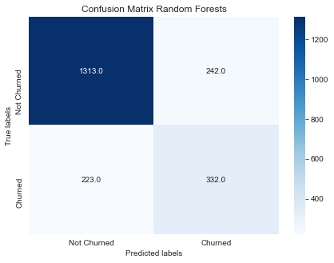

```python
#plotting a confusion matrix
labels = ['Not Churned', 'Churned']
plt.figure(figsize=(7,5))
ax= plt.subplot()
sns.heatmap(confusion_matrix_forest,cmap="Blues",annot=True,fmt='.1f', ax = ax); #annot=True to annotate cells

# labels, title and ticks
ax.set_xticklabels(labels)
ax.set_yticklabels(labels)
ax.set_xlabel('Predicted labels');ax.set_ylabel('True labels');
ax.set_title('Confusion Matrix Random Forests');
```

```python
from sklearn.metrics import classification_report
print(classification_report(y_test, y_pred_GBC))
```

```
              precision    recall  f1-score   support

           0       0.85      0.84      0.85      1555
           1       0.58      0.60      0.59       555

    accuracy                           0.78      2110
   macro avg       0.72      0.72      0.72      2110
weighted avg       0.78      0.78      0.78      2110
```

Fine tuning using Random search.

```python
gb_clf = GradientBoostingClassifier(random_state=42)
skfold = StratifiedKFold(n_splits=5)
param_grid = {
              'n_estimators' : [25, 50 ,75, 100, 200],
              'learning_rate': [0.005 ,0.05, 0.5, 1.5],
              'max_depth': [2, 4, 6, 8],
              'max_features': [10, 12, 17]
              }
random_gb_clf = RandomizedSearchCV(gb_clf, param_grid, cv=skfold, scoring="accuracy", n_jobs= -1, verbose = 1)
random_gb_clf.fit(X_train_res,y_train_res)
```

```
Fitting 5 folds for each of 10 candidates, totalling 50 fits
```

```
RandomizedSearchCV(cv=StratifiedKFold(n_splits=5, random_state=None, shuffle=False),
                   estimator=GradientBoostingClassifier(random_state=42),
                   n_jobs=-1,
                   param_distributions={'learning_rate': [0.005, 0.05, 0.5,
                                                          1.5],
                                        'max_depth': [2, 4, 6, 8],
                                        'max_features': [10, 12, 17],
                                        'n_estimators': [25, 50, 75, 100, 200]},
                   scoring='accuracy', verbose=1)
```

```python
random_gb_clf.best_params_
```

```
{'n_estimators': 75, 'max_features': 10, 'max_depth': 6, 'learning_rate': 0.5}
```

```python
GBC_best_Rand=GradientBoostingClassifier(random_state=42,learning_rate = 0.05,max_depth = 8,max_features =10,n_estimators = 100)
GBC_best_Rand.fit(X_train_res, y_train_res)
```

```
GradientBoostingClassifier(learning_rate=0.05, max_depth=8, max_features=10,
                           random_state=42)
```

```python
y_pred_GBCR=GBC_best_Rand.predict(X_test)
```

Evaluating Gradiant booster classifier.

```python
confusion_matrix_Rand = confusion_matrix(y_test, y_pred_GBCR)
print(confusion_matrix_forest)
```

```
[[1313  242]
 [ 223  332]]
```

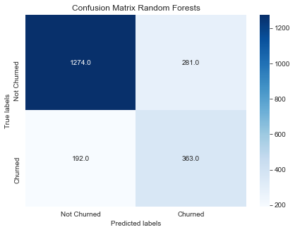

```python
#plotting a confusion matrix
labels = ['Not Churned', 'Churned']
plt.figure(figsize=(7,5))
ax= plt.subplot()
sns.heatmap(confusion_matrix_Rand,cmap="Blues",annot=True,fmt='.1f', ax = ax); #annot=True to annotate cells

# labels, title and ticks
ax.set_xticklabels(labels)
ax.set_yticklabels(labels)
ax.set_xlabel('Predicted labels');ax.set_ylabel('True labels');
ax.set_title('Confusion Matrix Random Forests')
```

```python
print(classification_report(y_test, y_pred_GBCR))
```

```
              precision    recall  f1-score   support

           0       0.87      0.82      0.84      1555
           1       0.56      0.65      0.61       555

    accuracy                           0.78      2110
   macro avg       0.72      0.74      0.72      2110
weighted avg       0.79      0.78      0.78      2110
```

After fine tuning using Gridsearch and Random search we can conclude that Grid search is showing better result in comparison with improved accuracy.